# Differential expression analysis: A pipeline to analyse time-course gene expression data

## Differential expression analysis of time-course data

The next step is typically to run a differential expression analysis. Most of `moanin`’s function rely on an object containing a number of information such as the metadata and the splines model used.

```r
splines_model = moanin::create_splines_model(meta, degrees_of_freedom=6)
```

### Weekly differential expression analysis

```r
meta$WeeklyGroup = make.names(meta$Group:as.factor(meta$Timepoint))

# Define contrast
contrasts = c("M.0-VL.0",
          "M.3-VL.3",
          "M.6-VL.6",
          "M.9-VL.9",
          "M.12-VL.12",
          "M.18-VL.18",
          "M.24-VL.24",
          "M.30-VL.30",
          "M.36-VL.36",
          "M.48-VL.48",
          "M.60-VL.60",
          "M.72-VL.72",
          "M.120-VL.120",
          "M.168-VL.168")
weekly_de_analysis =  moanin::weekly_differential_expression_analysis(
     data, splines_model, contrasts,
     use_voom_weights=FALSE)
```

Let’s look at the distribution of genes found differentially expressed per week between control and each of the influenza strains.

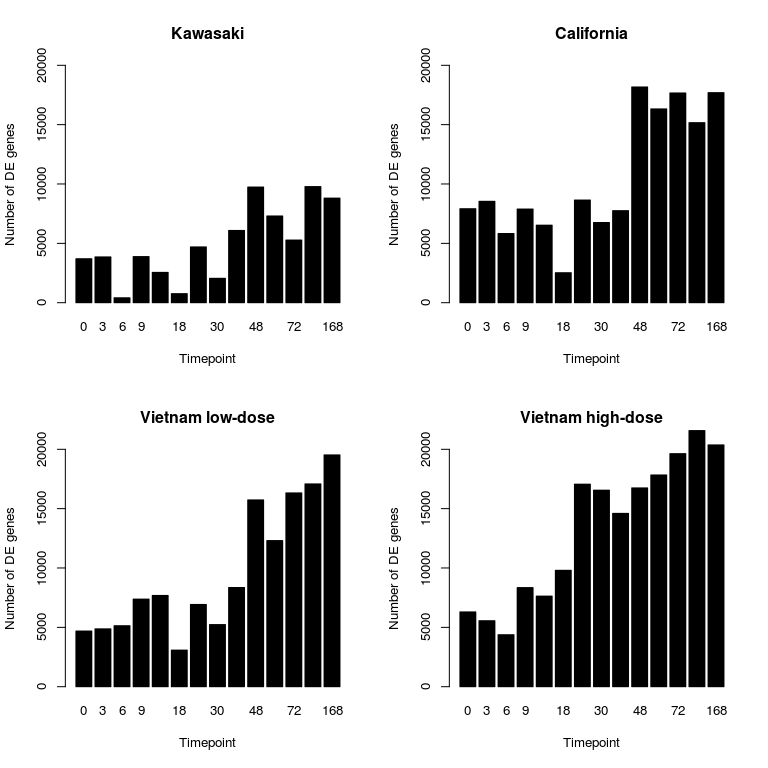

The distribution of number of genes found differentially expressed by considering each time-point independantly highlights the challenges of such approach. Timepoint 6H and 18H of the Kawasaki strain have fewer numbers of genes found differentially expressed than timepoints 3H and 9H: this is likely due to biological or technical variances for specific genes at specific timepoints.

As a summary, classic differential expression methods are appropriate for unordered treatments, but fail to use the temporal structure of the data.

### Time-course differential expression analysis between two groups

To leverage this temporal structure, Storey et al (Storey et al. 2005) proposes to model time-course micro-array with splines functions, and to use a log-ratio likelihood test to detect differentially expressed genes. `moanin` extends this idea by providing functions to perform time-course differential expression analysis using `limma` contrasts.

```r
# Define contrast
contrasts = limma::makeContrasts(
    contrasts=timecourse_contrasts,
    levels=levels(meta$Group))

# The function takes the data (data.frame or named matrix), the meta data
# (data.frame containing a timepoint and group column, the first corresponding
# to the time-course information, the latter corresponding to the
# treatment).
pvalues = moanin::timecourse_differential_expression_analysis(
    data, splines_model, contrasts)
qvalues = apply(pvalues, 2, stats::p.adjust)
```

The number of genes found differentially expressed ranges from around 12000 to 29000 depending on the strain and dosage of influenza virus given to the mice. This corresponds to between 30% to 70% of the genes found differentially expressed in this time-course experiment.

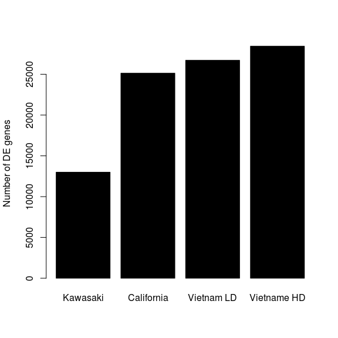

The next step in a classical differential expression analysis is typically to assess the effect of the treatment by looking at the log fold change. Computing the log fold change on a time-course experiment is not trivial: one can be interested in the average log-fold change across time, or the cumulative log-fold change. Sometimes a gene can be over-expressed at the beginning of the time-course data, and then over-expressed at the end of the experiment. As a result, `moanin` provides a number of possible ways to compute the log fold change across the whole time-course.

First, `moanin` provides as simple interface to compute the log-fold change for each individual timepoints.

```r
log_fold_change_timepoints = moanin::estimate_log_fold_change(
    data, splines_model, contrasts,  method="timely")
```

|  | M-K:1 | M-K:7 | M-K:11 | M-K:14 | M-K:2 |
| --- | --- | --- | --- | --- | --- |
| NM_009912 | -0.5662398 | -0.2454676 | -0.4096932 | -0.3320085 | -0.0502552 |
| NM_008725 | 0.9947059 | -3.4609546 | 0.6561484 | -1.2106329 | -0.1998796 |
| NM_007473 | -0.5176866 | -0.3146529 | 0.2327960 | -0.3445581 | 0.0476160 |
| ENSMUST00000094955 | -0.2201803 | 0.2566677 | -0.0358376 | -0.0469726 | -0.0707469 |
| NM_001042489 | -0.2475888 | -0.2043850 | -0.3428368 | -0.3930846 | -0.4821660 |
| NM_008159 | -0.7466435 | -0.0678902 | -0.3072220 | -0.7067393 | -0.4966867 |

This matrix can then be used to visualize the log-fold change for each contrast per timepoint.

Sometimes, a single value per gene and per contrast is more useful. Here is a table of the possible ways to compute log-fold change values.

[output not shown]

```r
log_fold_change_epicon = moanin::estimate_log_fold_change(
    data, splines_model, contrasts,  method="epicon")

log_fold_change_sum = moanin::estimate_log_fold_change(
    data, splines_model, contrasts,  method="sum")

log_fold_change_max = moanin::estimate_log_fold_change(
    data, splines_model, contrasts, method="max")

log_fold_change_min = moanin::estimate_log_fold_change(
    data, splines_model, contrasts, method="min")
```

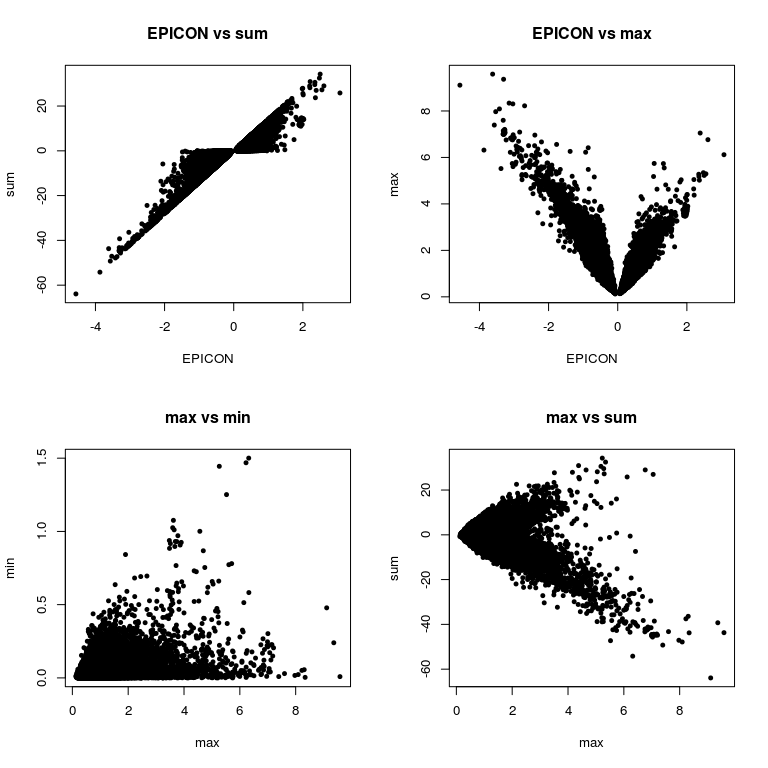

From the single measures of log-fold change and the p-value, we can now look at the volcano plot. Here is an example of a volcano plot for the comparaison of the control to the Kawasaki strain, using the EPICON log fold change computation.

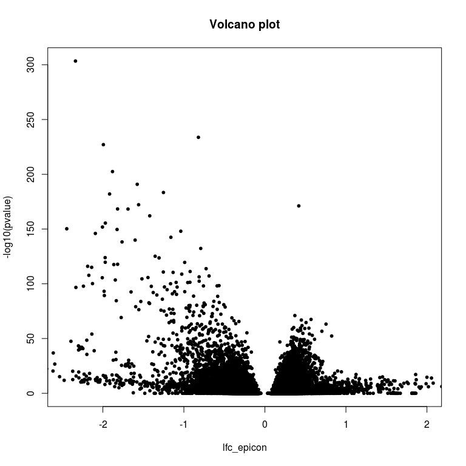

```r
pvalue = qvalues[, "M-K"]
lfc_epicon = log_fold_change_epicon[, "M-K"]
names(lfc_epicon) = row.names(log_fold_change_epicon)

plot(lfc_epicon, -log10(pvalue), pch=20, main="Volcano plot",
     xlim=c(-2.5, 2))
```

As another sanity check, `moanin` provides a simple utility function to visualize gene time-course data. Here, we plot the 12 genes with the smallest p-values.

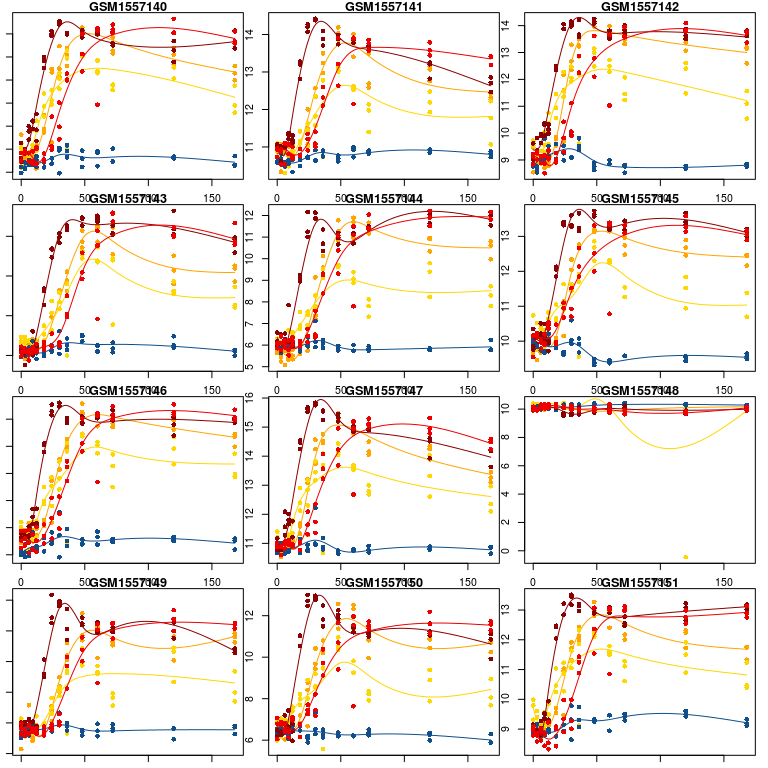

```r
top_DE_genes_pval = names(sort(pvalue)[1:12])
moanin::plot_genes(data[top_DE_genes_pval, ], splines_model,
           colors=ann_colors$Group, smooth=TRUE)
```

And here we visualize the genes with the largest absolute EPICON log-fold change.

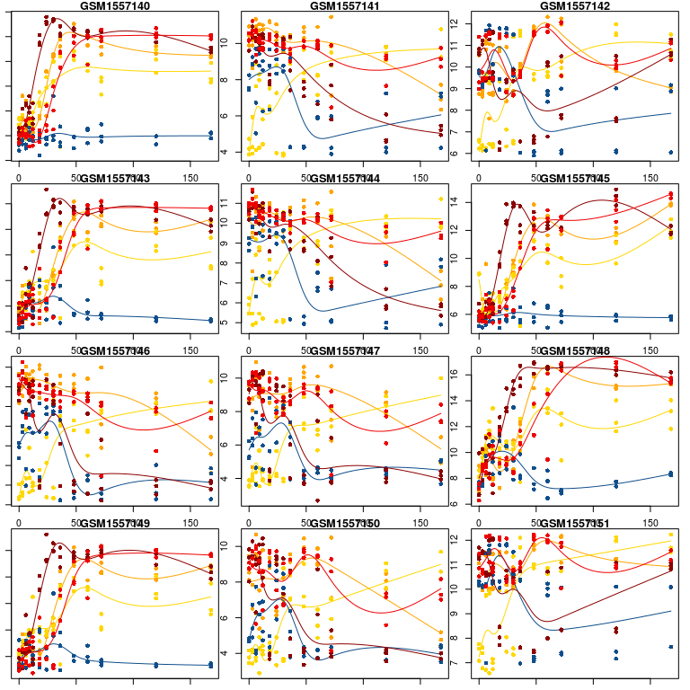

```r
top_DE_genes_lfc = names(
    sort(abs(lfc_epicon),
     decreasing=TRUE)[1:12])
moanin::plot_genes(data[top_DE_genes_lfc, ], splines_model,
           colors=ann_colors$Group, smooth=TRUE)
```

Thanks to those visualization, we can see that genes often follow similar patterns of expression, although on a different scale for each gene. We can leverage this observation to cluster the genes into groups of similar patterns of transcriptomic response.

# References

Storey, J. D., W. Xiao, J. T. Leek, R. G. Tompkins, and R. W. Davis. 2005. “Significance analysis of time course microarray experiments.” *Proc. Natl. Acad. Sci. U.S.A.* 102 (36): 12837–42.